# Day 10 Activities

Scout Leonard

8/20/2021

```r
ice_duration_data <- read_csv(here::here("data", "ntl33_v7.csv"), na = c("-999"))
meteorological_data <- read_csv(here::here("data", "ntl20_v6.csv"), na = c("-999"))
```

*Create a visualization that compares ice duration across different lakes in the Madison Lake Area. Include both the actual ice duration values and some representation of summary statistics for each lake. Careful if you use a boxplot over a jitter or beeswarm - what values might be doubly represented? Can you find an argument that would help you remove those from the boxplot?*

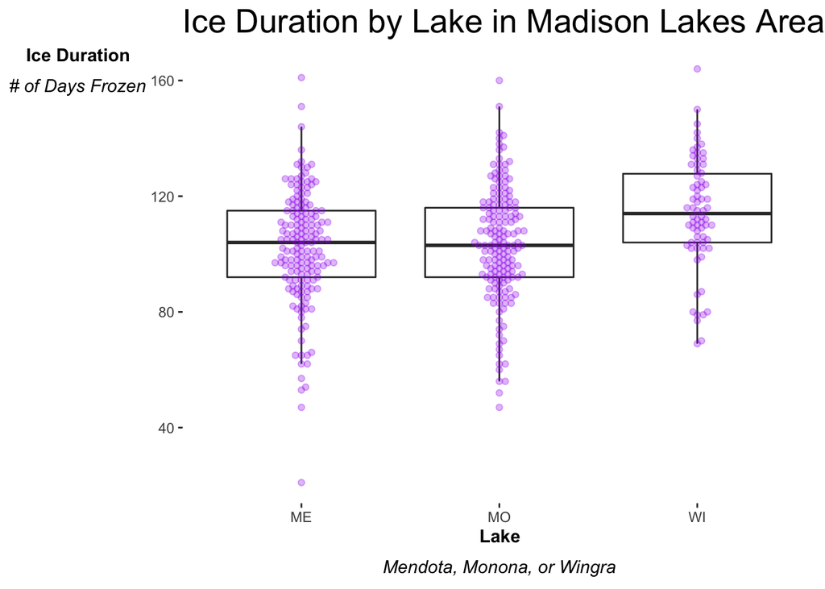

```r
ggplot(data = ice_duration_data, aes(x = lakeid, y = ice_duration)) +
  geom_boxplot(outlier.alpha = 0) +
  geom_beeswarm(color = "purple", alpha = 0.3) +
  labs(title = "Ice Duration by Lake in Madison Lakes Area",
       x = expression(atop(bold("Lake"), italic("Mendota, Monona, or Wingra"))),
       y = expression(atop(bold("Ice Duration"), italic("# of Days Frozen")))) +
  theme(axis.title.y = element_text(angle = 0),
        plot.title = element_text(size = 20),
        panel.background = element_blank())
```

I used a boxplot over a beeswarm plot. This means that the outliers on the bowpltos were doubly represented as points on my graph. I was able to remove the outliers from the bowplot by specifying the outlier.alpha as 0 like this `geom_boxplot(outlier.alpha = 0)`.

*Find the mean ice cover duration in Madison Lake Area by year (i.e., you’ll only be grouping by the year variable here). Understanding check: what are you finding the mean of here? Why are there multiple observations for each year?)*

```r
ice_subset <- ice_duration_data %>%
  group_by(year4) %>%
  summarize(mean_duration = mean(ice_duration, na.rm = TRUE))
```

There are multiple observations for each year because observations are from each of the three lakes. Here I found the mean ice duration of the three lakes for each year in the dataset.

*Create an exploratory visualization of mean ice cover duration by year for the Madison Lake Area. Add a sentence or two below this exploratory graph describing the overall trend(s) you observe.*

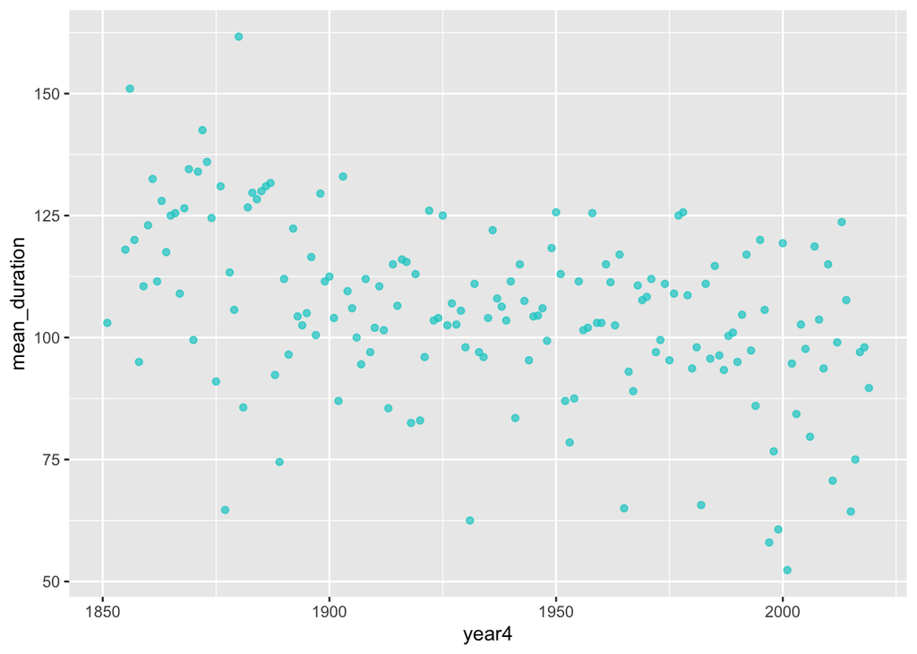

```r
ggplot(ice_subset, aes(x = year4, y = mean_duration)) +
  geom_point(color = "cyan3", alpha = 0.7)
```

The overall trend observed is that duration of ice on lakes has gradually decreased in the last century.

*Find the mean air temperature (using the daily average air temperature - adjusted) in Madison Lake Area by year using only observations from winter months (December, January, February)*

```r
meteorological_months <- meteorological_data %>%
  mutate(date = lubridate::ymd(sampledate)) %>%
  mutate(month = month(sampledate))

winter_subset <- meteorological_months %>%
  filter(month == c(12, 1, 2)) %>%
  group_by(year4) %>%
  summarize(mean = mean(ave_air_temp_adjusted))
```

*Create an exploratory visualization of mean winter temperatures for the Madison Lake Area. Add a sentence or two below this exploratory graph describing the overall trend(s) you observe.*

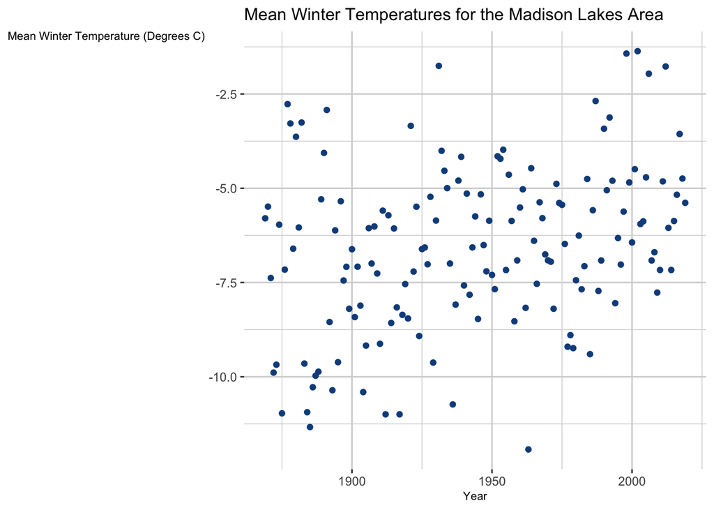

```r
ggplot(data = winter_subset, aes(x = year4, y = mean)) +
  geom_point(color = "dodgerblue4") +
  theme(panel.background = element_blank(),
        panel.grid = element_line(color = "lightgrey"),
        axis.title.y = element_text(angle = 0, size = 8),
        axis.title.x = element_text(size = 8),
        plot.title = element_text(size = 12)) +
  labs(title = "Mean Winter Temperatures for the Madison Lakes Area",
       x = "Year",
       y = "Mean Winter Temperature (Degrees C)")
```

```r
temp_ice_join <- winter_subset %>%
  full_join(ice_subset)
```

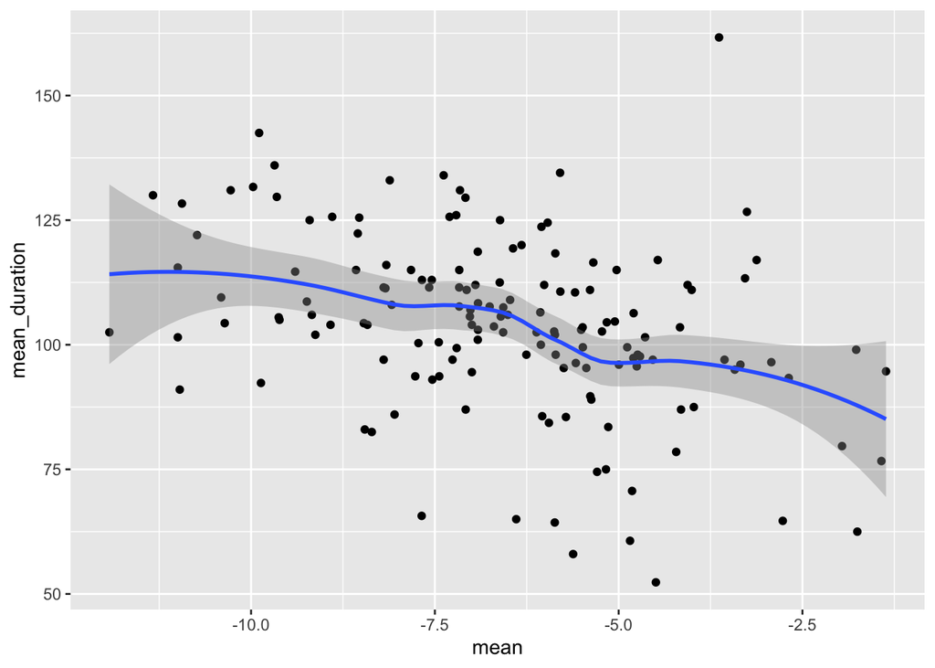

```r
ggplot(data = temp_ice_join, aes(x = mean, y = mean_duration)) +
  geom_point() +
  geom_smooth()
```

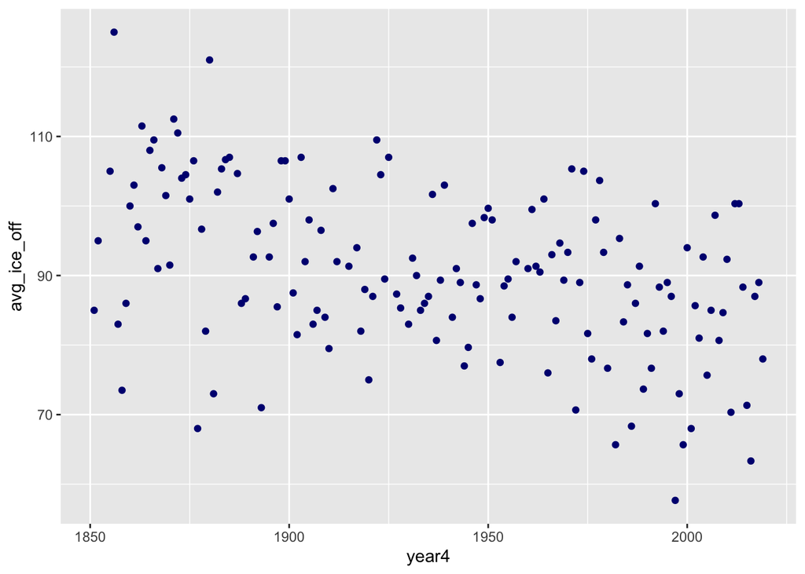

```r
ice_off_data <- ice_duration_data %>%
  mutate(ice_off_date = lubridate::ymd(ice_off)) %>%
  mutate(day_of_yr_ice_off = yday(ice_off_date))



ice_off_subset <- ice_off_data %>%
  group_by(year4) %>%
  summarize(avg_ice_off = mean(day_of_yr_ice_off))

ggplot(data = ice_off_subset, aes(x = year4, y = avg_ice_off)) +
  geom_point(color = "navy")
```